# 31 Flavors of Miami and other Benchmark Soils

Stephen Roecker, Skye Wills

2018-06-29

## SDJR 2.0?

- What makes a soil map unit (SMU) component different from a soil series?
- What makes a SMU components different from each other?
- How different are SMU components from each other?
- How many SMU components are necessary to capture the full range of variation in a soil series?

## Soil Series and Benchmark Soil Series

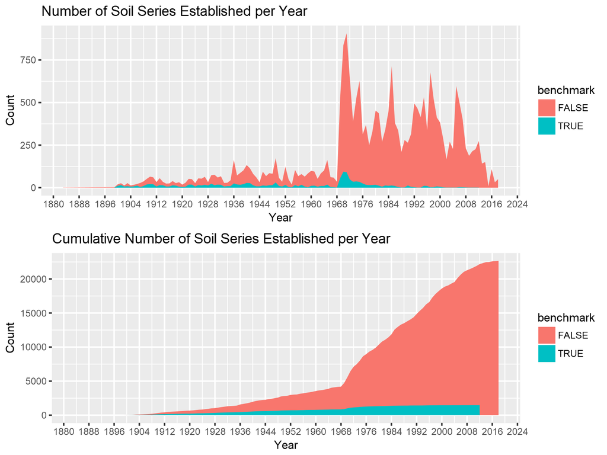

## Soil Map Unit Components (SSURGO)

| Type | Count |
| --- | --- |
| Soil Series (SS) | 25689 |
| Benchmark SS | 1478 |
| Soil Map Unit Components | 645607 |

## How Do We Phase Components?

- Surface texture
- Slope gradient
- Erosion class
- Flooding frequency
- Substratum
- …

## How Have We Historically Populated Components?

1. One or Several Typical Pedons (RV) for a Soil Series (e.g. SOI-5)
2. Typical Pedon (RV) from the Soil Survey Area
   - Ranges (L & H) from OSD
   - Ranges (L & H) derived locally
3. Copying and pasting

## What Future Challenges Do We Face?

- How do we manage over 645,000 components?
- “Work Smarter not Harder” examples:
  - Harder
    - John Henry vs. the Steam Engine or
    - Sarah Connor vs. the Terminator (Terminator 1)
  - Smarter
    - John Conner with the Terminator (Terminator 2)
- Incorporated Dynamic Soil Properties
- Embrace technology (easier said than done)!

# Depth Plots of Benchmark Soil Series

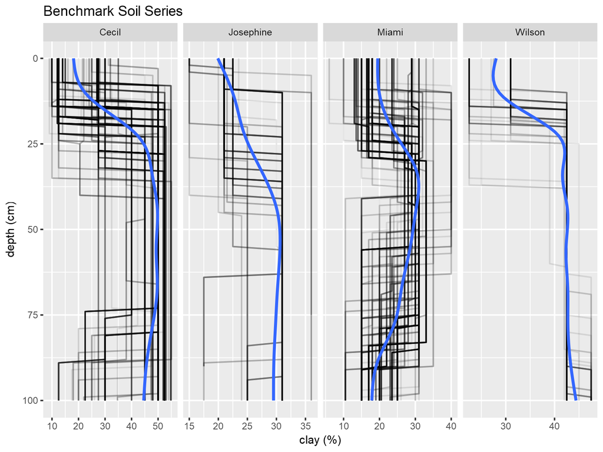

## Miami Depth Plots - Landform

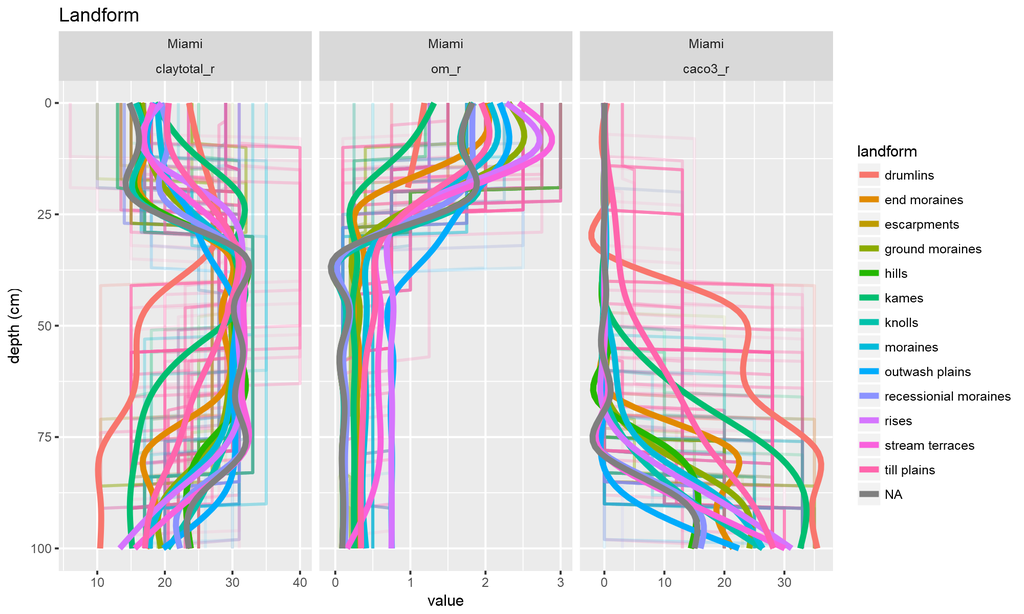

## Miami Depth Plots - Parent Material

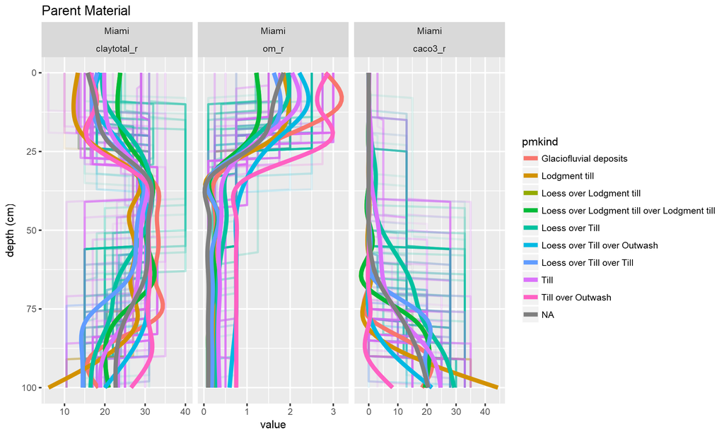

# Miami Heatmap - Landform vs Parent Material

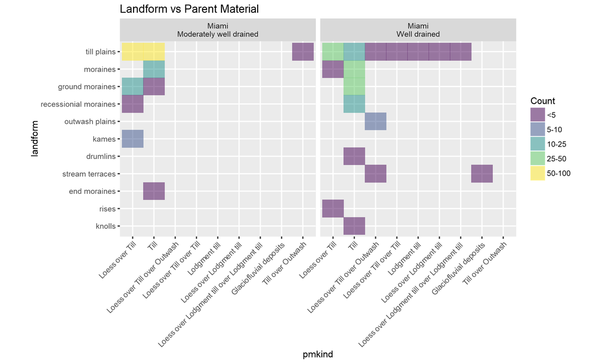

## Miami Depth Plots - Slope Phase

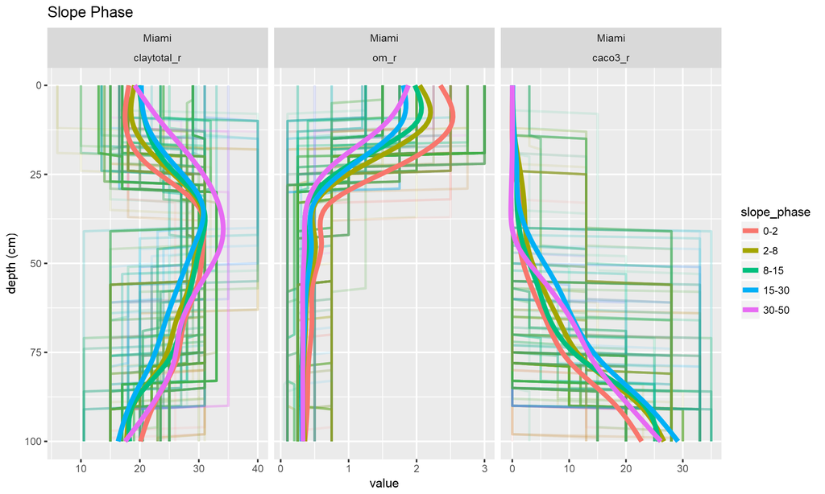

## Miami Depth Plots - Surface Texture

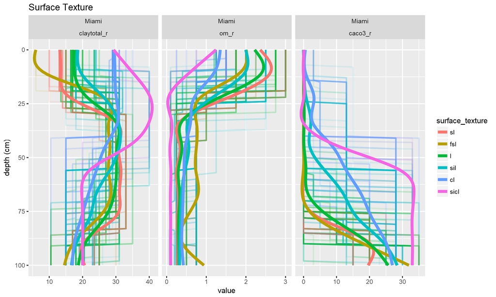

## Miami Depth Plots - Erosion Class

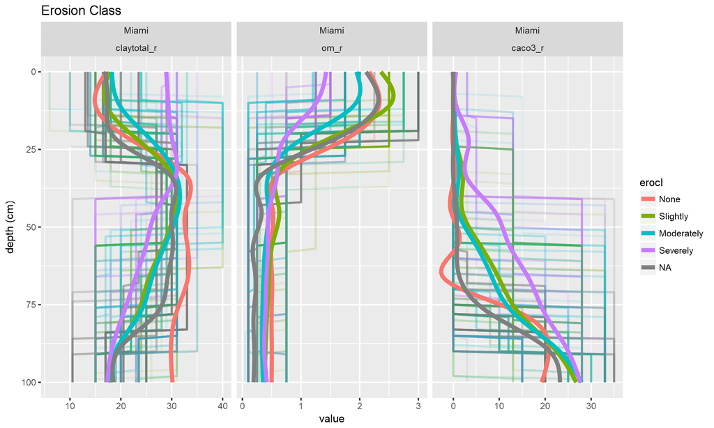

# Miami Depth Plots - Hierarchical Clusters

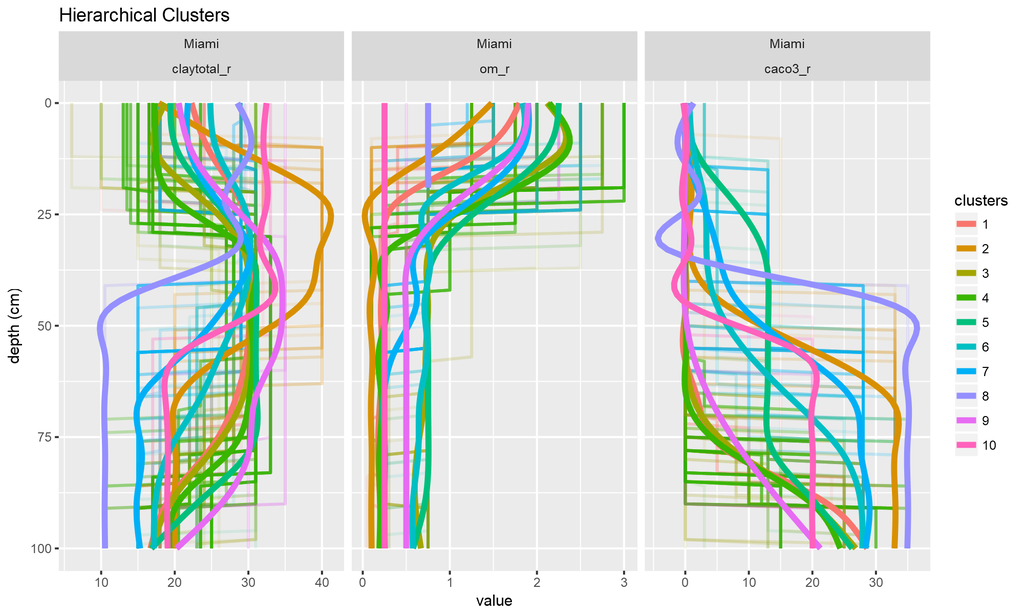

## How Many Unique Combinations Exist?

- Tier 1 Phases = surface teture + slope + erosion class + flooding frequency
- Tier 2 Phases = Tier 1 + landform + parent material
- Unique Horizons 1 = horizon depths + clay content
- Unique Horizons 2 = unique horizons 1 + organic matter + carbonates

| compname | n_majcompflag | n_tier1 | n_tier2 | n_unique_h1 | n_unique_h2 |
| --- | --- | --- | --- | --- | --- |
| Gilpin | 905 | 101 | 279 | 256 | 274 |
| Cecil | 442 | 82 | 161 | 140 | 142 |
| Miami | 368 | 53 | 138 | 133 | 151 |
| Josephine | 127 | 25 | 53 | 37 | 38 |
| Tama | 98 | 14 | 40 | 30 | 33 |
| Drummer | 34 | 5 | 19 | 21 | 22 |
| Wilson | 73 | 14 | 19 | 60 | 60 |

## Interpretations

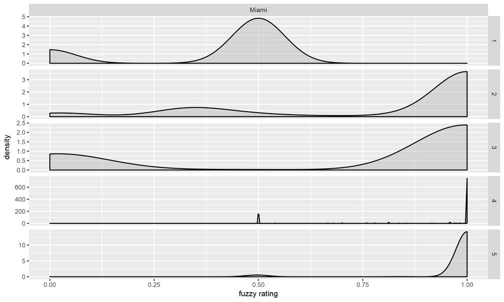

## Interpretations

| rule_number | interp |
| --- | --- |
| 1 | AGR - Pesticide Loss Potential-Leaching |
| 6 | AWM - Land Application of Municipal Sewage Sludge |
| 28 | ENG - Dwellings With Basements |
| 30 | ENG - Local Roads and Streets |
| 33 | ENG - Septic Tank Absorption Fields |

## Conclusions & Recommendations

- This analysis suggests the total number of soil components could be reduced to a more manageable number without compromising the level of detail they contain.
- Numerous components have the same or very similar horizon data.
- A limited selection of interpretations show that only 4 types of Miami necessary.
- Reduce the number of components by developing a representative set of component phases for each soil series and link to the appropriate soil map unit.